# Analysis

# Introduction

Comparing the accuracy of field measurements of patch reefs versus using satellite imagery to measure patch reefs in Kanoehe Bay.

# Methods

# Results

## Effect of method (field vs imagery) on accuracy of patch reef area measurement

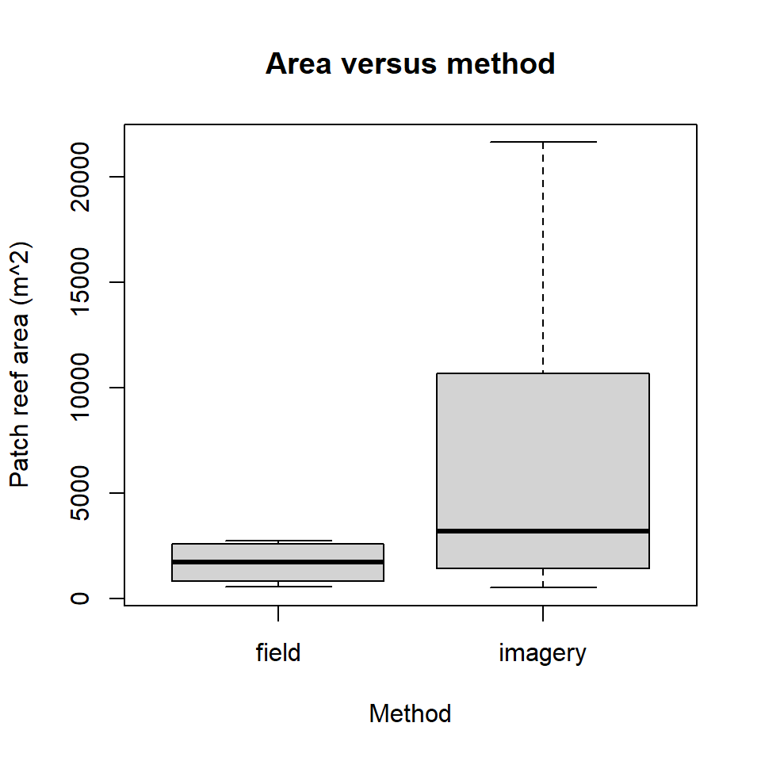

## Effect of method (field vs imagery) on accuracy of patch reef area measurement with only high resolution (0.15m) imagery

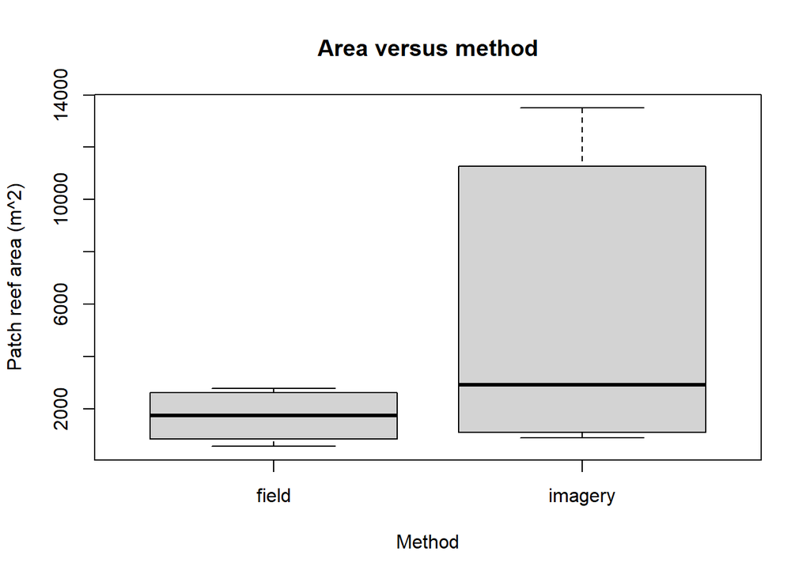

## Effect of resolution on measurement accuracy

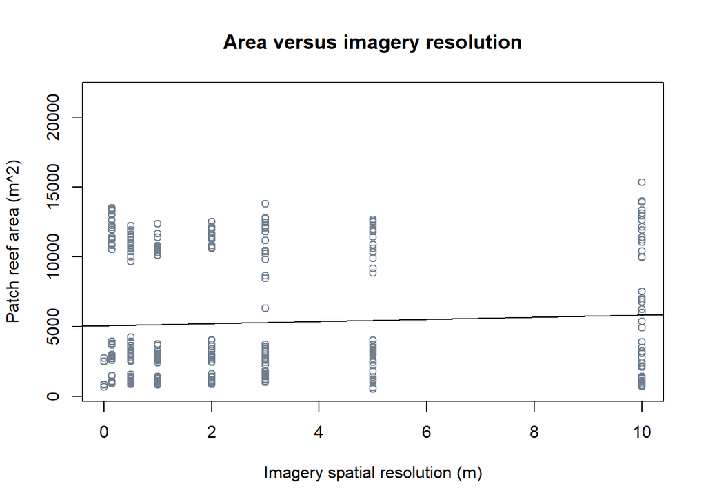

```
##
## Call:
## lm(formula = area_m2 ~ imagery_resolution_m, data = data)
##
## Residuals:
##    Min     1Q Median     3Q    Max
##  -6778  -3998  -2180   5421  14229
##
## Coefficients:
##                      Estimate Std. Error t value Pr(>|t|)
## (Intercept)           5072.84     282.30  17.970   <2e-16 ***
## imagery_resolution_m    78.28      25.52   3.068   0.0023 **
## ---
## Signif. codes:  0 '***' 0.001 '**' 0.01 '*' 0.05 '.' 0.1 ' ' 1
##
## Residual standard error: 4743 on 409 degrees of freedom
##   (13 observations deleted due to missingness)
## Multiple R-squared:  0.02249,    Adjusted R-squared:  0.0201
## F-statistic: 9.411 on 1 and 409 DF,  p-value: 0.0023
```

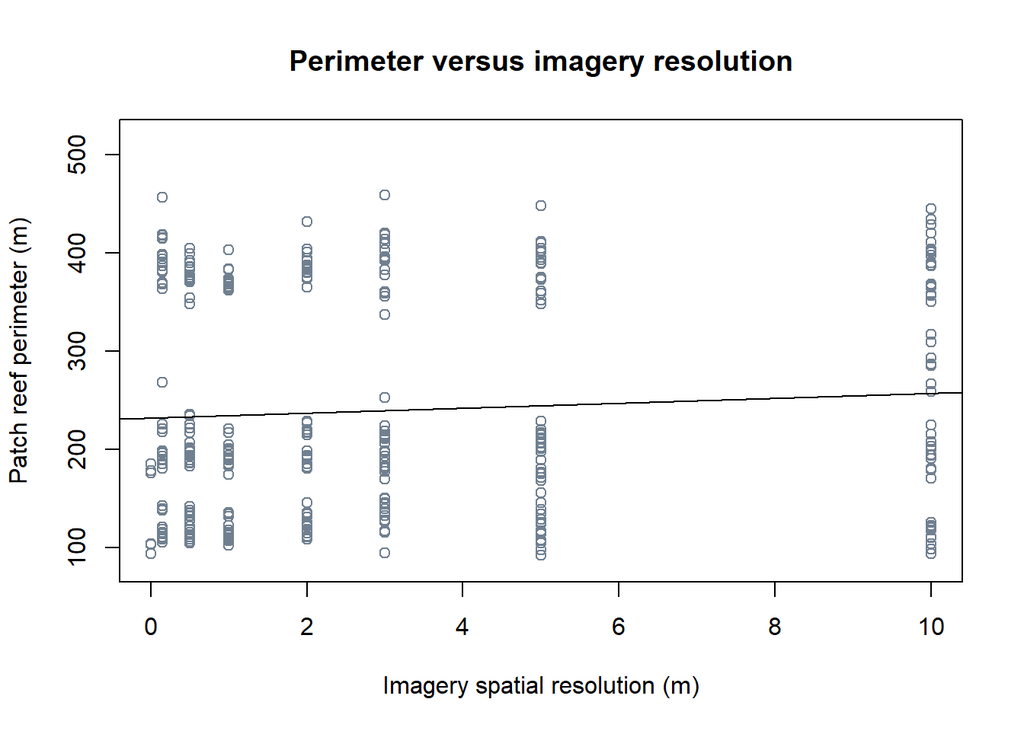

```
##
## Call:
## lm(formula = perimeter_m ~ imagery_resolution_m, data = data)
##
## Residuals:
##     Min      1Q  Median      3Q     Max
## -223.77 -103.16  -35.71  132.02  224.23
##
## Coefficients:
##                      Estimate Std. Error t value Pr(>|t|)
## (Intercept)          232.3348     6.8210  34.062  < 2e-16 ***
## imagery_resolution_m   2.4813     0.6166   4.024  6.8e-05 ***
## ---
## Signif. codes:  0 '***' 0.001 '**' 0.01 '*' 0.05 '.' 0.1 ' ' 1
##
## Residual standard error: 114.6 on 409 degrees of freedom
##   (13 observations deleted due to missingness)
## Multiple R-squared:  0.03809,    Adjusted R-squared:  0.03574
## F-statistic:  16.2 on 1 and 409 DF,  p-value: 6.805e-05
```

## Effect of year on reef measurement

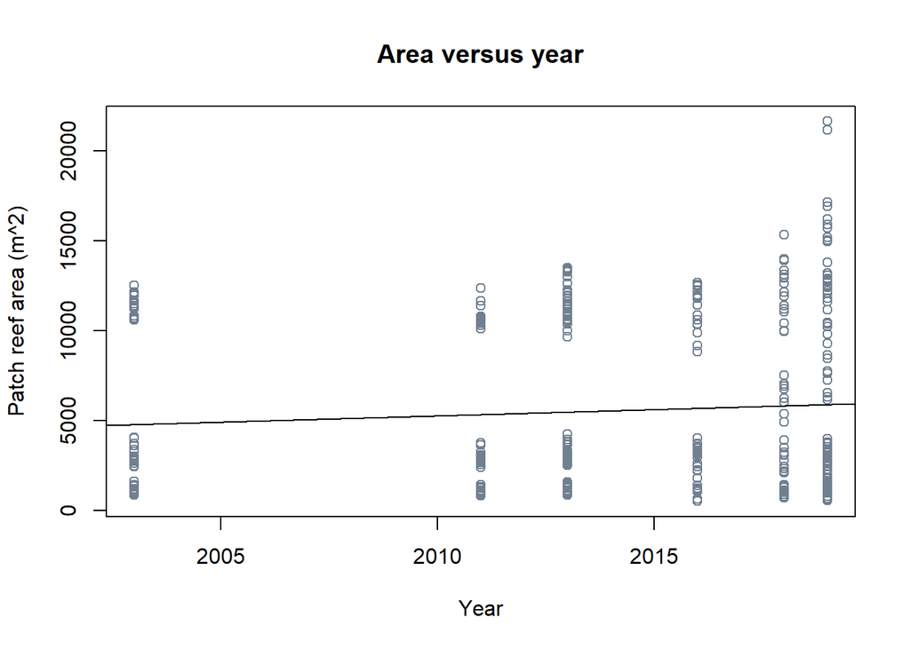

```
##
## Call:
## lm(formula = area_m2 ~ as.numeric(year), data = data)
##
## Residuals:
##    Min     1Q Median     3Q    Max
##  -5346  -4016  -2413   5288  15743
##
## Coefficients:
##                    Estimate Std. Error t value Pr(>|t|)
## (Intercept)      -136177.84   94594.12  -1.440    0.151
## as.numeric(year)      70.37      46.97   1.498    0.135
##
## Residual standard error: 4784 on 409 degrees of freedom
##   (13 observations deleted due to missingness)
## Multiple R-squared:  0.005459,   Adjusted R-squared:  0.003028
## F-statistic: 2.245 on 1 and 409 DF,  p-value: 0.1348
```

## Discussion

Field measurements of patch reefs were less variable than using satellite imagery. Furthermore, the reefs do not appear to significantly grow over time which means that we are able to use a range of years of satellite imagery for our analysis.